# DATA 607 Assignment 2

Fan Xu

9/8/2019

## Assignement 2 - SQL and R

Choose six recent popular movies. Ask at least five people that you know (friends, family, classmates, imaginary friends) to rate each of these movie that they have seen on a scale of 1 to 5. Take the results (observations) and store them in a SQL database. Load the information into an R dataframe.

Your deliverables should include your SQL scripts and your R Markdown code, posted to GitHub.

This is by design a very open ended assignment. A variety of reasonable approaches are acceptable. You can (and should) blank out your SQL password if your solution requires it; otherwise, full credit requires that your code is “reproducible,” with the assumption that I have the same database server and R software. You may work in a small group.

## 1 Connect R to MySQL

Note: User name and password is hid with comment echo=FALSE.

```r
library(kableExtra)
library(RMySQL)
library(RODBC)
conn <- dbConnect(MySQL(), user= usr, password = pwd, dbname='data607', host='localhost')
```

## 2 Prepare the required data set and store it in MySQL

The data set is store in MySQL with the SQL script in the link below.

[Link to Github](https://raw.githubusercontent.com/oggyluky11/DATA607-Assignment-2/master/Movie%20data.sql)

An alternate way is to upload the data set to MySQL through R.

```r
movies = read.csv("https://raw.githubusercontent.com/oggyluky11/DATA607-Assignment-2/master/Movies.csv")
#Be cautious with argument OVERWRITE when executing dbWriteTable function, original data table in MySQL would be overwriten if table with identical name exists.
dbWriteTable(conn,"movies",movies, row.names = FALSE, overwrite = TRUE)
```

```
## [1] TRUE
```

## 3 Load the data set into R as dataframe

```r
SQLMovieData <- dbGetQuery(conn, "select * from movies")
SQLMovieData
```

| Friend | Movie_1_Iron_Man_II | Movie_2_Captain_America_III | Movie_3_Doctor_Strange | Movie_4_Avengers_III | Movie_5_Avengers_VI | Movie_6_Black_Panther |
| --- | --- | --- | --- | --- | --- | --- |
| Silas | 5 | NULL | NULL | NULL | 5 | 3 |
| Theodore | NULL | 5 | 2 | 4 | 5 | 3 |
| Jack | 5 | 5 | 3 | NULL | 5 | NULL |
| Finn | 5 | NULL | 5 | NULL | NULL | 3 |
| Aarav | 3 | 5 | 4 | NULL | 5 | 2 |
| Felix | NULL | NULL | 4 | 5 | 4 | NULL |
| Henry | NULL | 1 | NULL | 4 | 5 | 1 |
| Wyatt | NULL | 4 | NULL | 4 | 5 | NULL |
| Aryan | 5 | 2 | NULL | 3 | 5 | NULL |
| Oscar | 2 | 2 | 3 | 5 | 5 | 5 |

[output cut: 15 more lines]

## 4 Visualization on the data set

Unpivot the original data set, making movie names as one column factor.

```r
library(reshape2)
ReshapedData <-melt(SQLMovieData, id.vars = c("Friend"))
names(ReshapedData)[2:3]<- c("Movie", "Rating")
ReshapedData$Rating<-as.numeric(ReshapedData$Rating)
ReshapedData
```

| Friend | Movie | Rating |
| --- | --- | --- |
| Silas | Movie_1_Iron_Man_II | 5 |
| Theodore | Movie_1_Iron_Man_II | NA |
| Jack | Movie_1_Iron_Man_II | 5 |
| Finn | Movie_1_Iron_Man_II | 5 |
| Aarav | Movie_1_Iron_Man_II | 3 |
| Felix | Movie_1_Iron_Man_II | NA |
| Henry | Movie_1_Iron_Man_II | NA |
| Wyatt | Movie_1_Iron_Man_II | NA |
| Aryan | Movie_1_Iron_Man_II | 5 |
| Oscar | Movie_1_Iron_Man_II | 2 |

[output cut: 140 more lines]

Plot of Ratings by each rator, rating score = 0 stand for null value (the rator haven’t watch the movie so no rating is given).

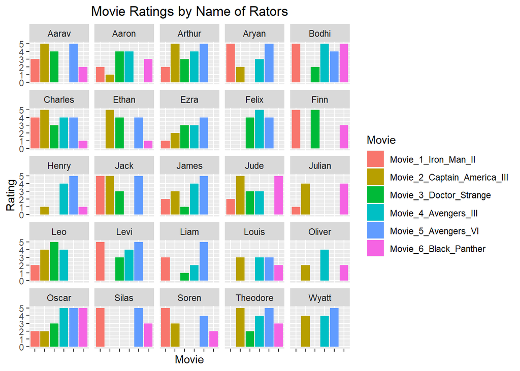

```r
library(ggplot2)
ggplot(data=ReshapedData, aes(x=Movie, y = Rating, fill = Movie, label = Rating))+
    geom_bar(stat="identity")+
    facet_wrap(~Friend)+
    ggtitle("Movie Ratings by Name of Rators")+
    theme(axis.text.x = element_blank(),plot.title = element_text(hjust=0.5),legend.position = "right")
```

Plot of average rating of each movie (There are various ways to manlipulate null values, but in this assignment they are ignored)

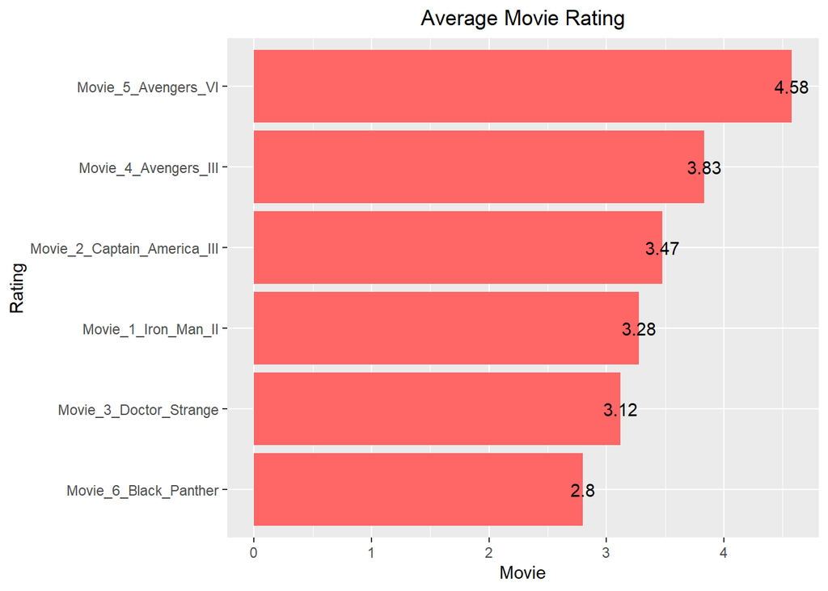

```r
PivotData = aggregate(Rating ~ Movie, data=ReshapedData,mean)
ggplot(data=PivotData, aes(x=(reorder(Movie, Rating)), y = Rating, label = Rating))+
  geom_bar(stat="identity", fill="#FF6666")+
  coord_flip()+
  labs(title="Average Movie Rating", x= "Rating", y = "Movie")+
  geom_text(aes(label=round(Rating, digits = 2)))+
  theme(plot.title=element_text(hjust=0.5))
```